# Public Health Graphical Display Using R

## GitHub repository with code, data, and slides for this workshop:

## https://github.com/mcSamuelDataSci/R-visual-display-workshop

## Link to Folder with HLML version of this document and all files for this workshop:

## https://goo.gl/DCVQCk

# Chapter 0.1 — Data Sets —

```r
myPlace <- getwd()
source('dataSetsLocal.R')
```

```r
library(gsheet)
source('dataSetsWeb.R')
```

### 10/2018 Draft - Work in Progress

Michael C. Samuel, Dr.P.H.  
Data Scientist / Senior Epidemiologist  
California Department of Public Health  
Michael.Samuel@cdph.ca.gov  
925-285-2926

Please contact Michael Samuel to report errors or for other suggestions

# Chapter 0.0 — Introduction —

R (like its parent S) is an unparalleled tool for producing high-quality visual displays. The power of R for visual display is based on its complete integration of data and graphics objects. Figures are produced using a wide range of excellent high and low level built-in graphical tools, project-specific custom code including functions, and a phenominal array of add-on “packages” built by users all over the world.

This overview describes the basic operation of the R graphical procedures, teaching by example, using data and examples from public heath surveillance. The details covered here only begin to scratch the surface of the power and complexity of R’s graphical display functionality.

You can learn a lot by looking at the built-in R examples and demos, with all code:

demo(graphics)  
example(barplot)  
example(title)  
example(hist)  
example(plot)  
example(matplot)  
example(boxplot)  
demo(plotmath)

par(ask=F)

Help/Getting Started Read/review “Graphical Procedures” Chapter (Chapter 12) in “An Introduction to R”

“Quick-R” site with “cookbook” approach to using R including graphics http://www.statmethods.net/index.html

Data Analysis and Graphics Using R - An Example-Based Approach http://maths-people.anu.edu.au/~johnm/r-book/daagur3.html

LOTs of helpful info on R graphics at: http://www.stat.auckland.ac.nz/~paul/RGraphics/rgraphics.html (including .pdf of introductory chapter and chapters on the grid and lattice packages and at: http://www.stat.auckland.ac.nz/~paul/

Gallary of R graphics and code, and some related links at: http://addictedtor.free.fr/graphiques/

Data Analysis and Graphics Using R - An Example-Based Approach. John Maindonald and John Braun. 2nd edn, Cambridge University Press, January 2007. Related info: http://maths.anu.edu.au/~johnm/r-book/daagur3.html

R Graphics-Related Packages and Other Links and Resources In addition to the core graphically functionality of R, the “lattice” and “grid” packages are included with the main R system download. They add a wide range of tools, particularity for complex multi-row and or muti-column figures,and for combining types of charts (e.g. Bar and line charts). When using lattice/grid graphics, you do not/can not use the “regular” R graphics functions or parameters.

“Trellis Graphics is a framework for data visualization developed at the Bell Labs by Rick Becker, Bill Cleveland et al, extending ideas presented in Bill Cleveland’s 1993 book *Visualizing Data*. Lattice is best thought of as an implementation of Trellis Graphics for R…Lattice is built upon the Grid Graphics engine for R … and requires the ‘grid’ add-on package. Type ‘help(package = lattice)’ to see a list of (public) Lattice graphics functions for which further documentation is available”.

“ggplot2 is a plotting system for R, based on the grammar of graphics, which tries to take the good parts of base and lattice graphics and avoid bad parts. It takes care of many of the fiddly details that make plotting a hassle (like drawing legends) as well as providing a powerful model of graphics that makes it easy to produce complex multi-layered graphics.” Find out more at http://had.co.nz/ggplot2, and check out the over 500 examples of ggplot in use"

There are hundreds of other graphics-related packages that may be of use generally or for specific types of plots.

Other Resources:  
Parameters and functions cheat-sheet: https://cran.r-project.org/doc/contrib/Baggott-refcard-v2.pdf  
Color advice: http://colorbrewer2.org/  
R color cheatsheet: https://www.nceas.ucsb.edu/~frazier/RSpatialGuides/colorPaletteCheatsheet.pdf  
R Studio cheat-sheets: https://www.rstudio.com/resources/cheatsheets/  
Anything Zev Ross says: http://zevross.com/blog/

# Chapter 1 — Graphical Parameters —

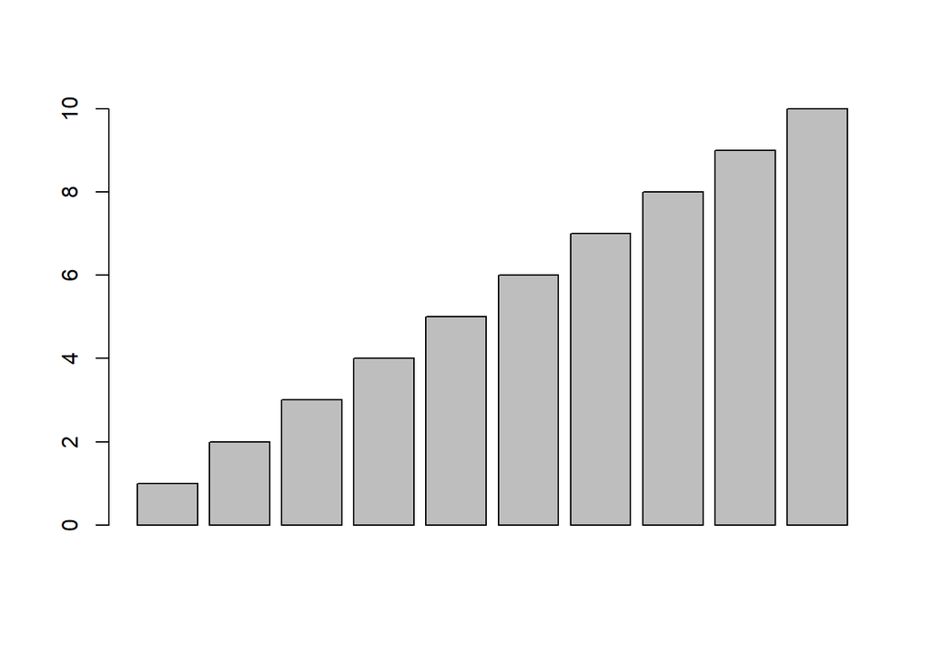

```r
barplot(1:10)
```

R plotting commands are divided into two main groups, High-Level, that are generally used to make new plots, and Low-Level, that are generally used to add things to plots. BOTH use *graphical parameters* to manipulate and customize plots.

Global parameters: change in all cases

```r
parsave <- par()       # save the default parameters
```

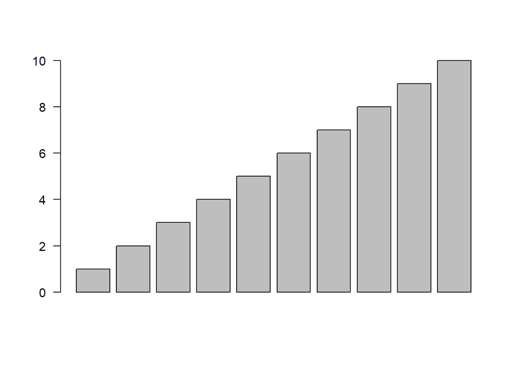

```r
par(las=1)  # specify horizontal axis labels label
barplot(1:10)
```

```r
par <-par(parsave)     # return to default parameters
```

Local parameters: change in the specific figure

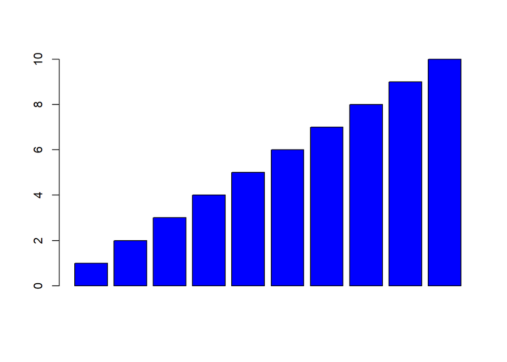

```r
barplot(1:10, col="blue")
```

List of all parameters

```r
help(par)
```

A large proportion of what you need to know about the parameters is on the R Reference card noted above. Parameters and functions cheat-sheet: https://cran.r-project.org/doc/contrib/Baggott-refcard-v2.pdf

# Chapter 2 — Simple Frequency Distribution Plots (e.g. histograms, boxplots) —

There are *many* excellent R graphical routines for looking at the frequency or distribution of a variable, including histograms, box plots, “strip plots”, and “density plots”.

hist(rnorm(100)) hist(rnorm(10000))

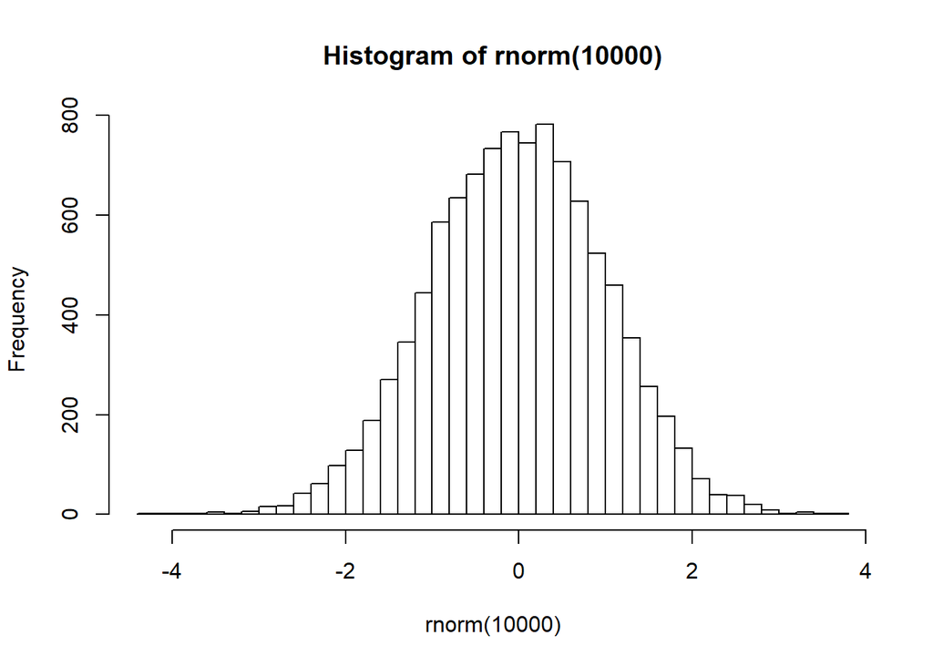

```r
hist(rnorm(10000),breaks=50)
```

### Get to know the gonorrhea male rate variable before plotting

```r
attach(usSTD) # Attach the usSTD data frame for convenience
gcm
```

```
##  [1] 239.0  88.9  83.4 168.2  80.5  86.2  80.7 188.7 533.1 140.7 223.8
## [12]  56.8   6.9 193.2 113.1  45.8  89.4  92.8 252.7  15.8 185.9  54.4
## [23] 139.5  55.9 194.7 152.3  10.5  77.4 100.4  11.4  96.3  80.1 116.9
## [34] 201.4  10.0 178.1 123.5  32.5 102.8  82.6 244.5  30.7 172.7 124.4
## [45]  19.9  14.1 144.5  58.9  46.2  98.6  10.9
```

```r
sort(gcm)
```

```
##  [1]   6.9  10.0  10.5  10.9  11.4  14.1  15.8  19.9  30.7  32.5  45.8
## [12]  46.2  54.4  55.9  56.8  58.9  77.4  80.1  80.5  80.7  82.6  83.4
## [23]  86.2  88.9  89.4  92.8  96.3  98.6 100.4 102.8 113.1 116.9 123.5
## [34] 124.4 139.5 140.7 144.5 152.3 168.2 172.7 178.1 185.9 188.7 193.2
## [45] 194.7 201.4 223.8 239.0 244.5 252.7 533.1
```

```r
summary(gcm)
```

```
##    Min. 1st Qu.  Median    Mean 3rd Qu.    Max.
##    6.90   55.15   92.80  112.78  160.25  533.10
```

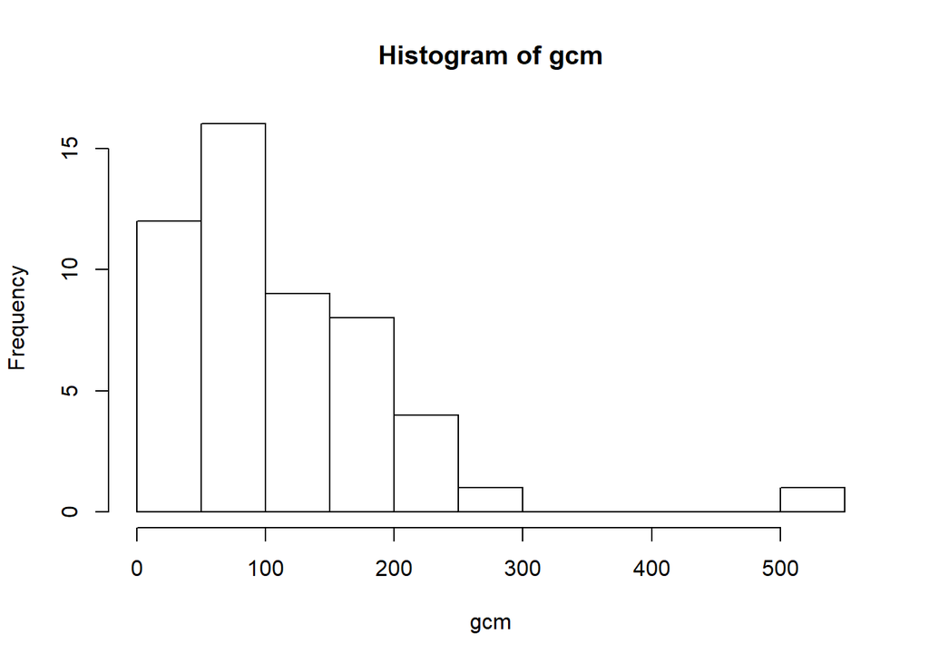

```r
hist(gcm,breaks=10)  # Histogram
```

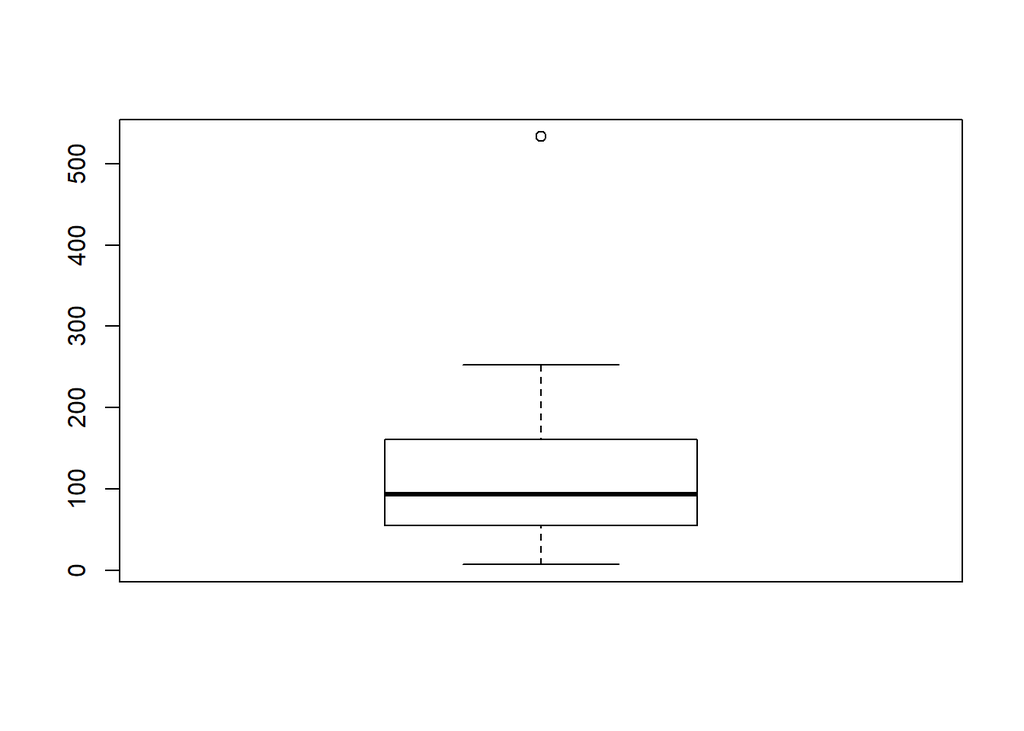

```r
boxplot(gcm)               # Box-plot
```

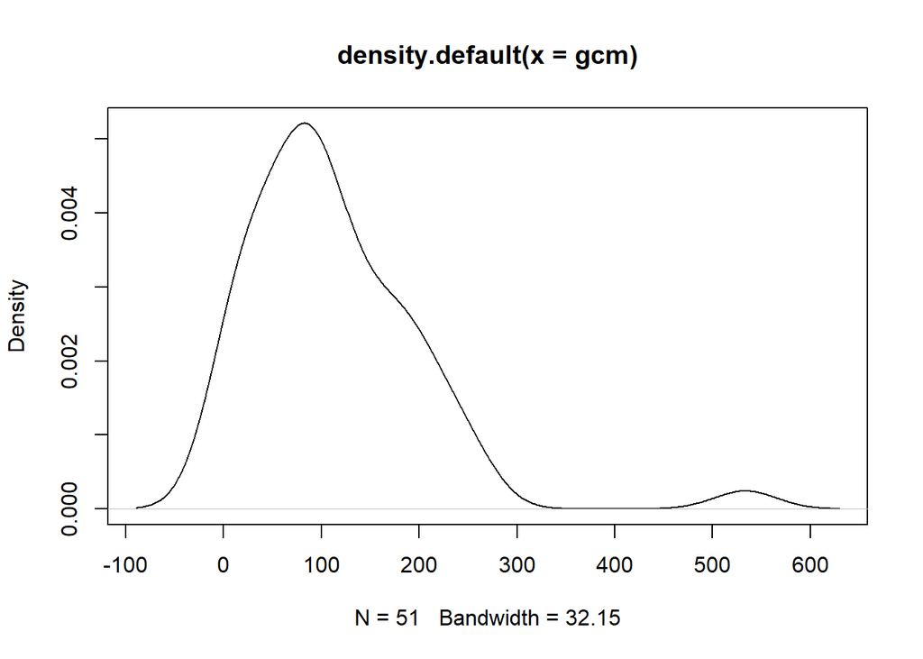

```r
plot(density(gcm))   # Density plot
```

```r
detach(usSTD)
```

# Chapter 3 — Simple Summary Plots (e.g. bar charts, pie charts) —

R has countless great routines to display summary data, like counts, percents and rates– bar plots, pie charts and dot charts are all such plots

## Simple Vertical Barplot

```r
attach(ca.gc)   # Attach the ca.gc data frame for convenience
```

```r
barplot(m.rate )
```

```r
barplot(m.rate,names.arg=names.short)
```

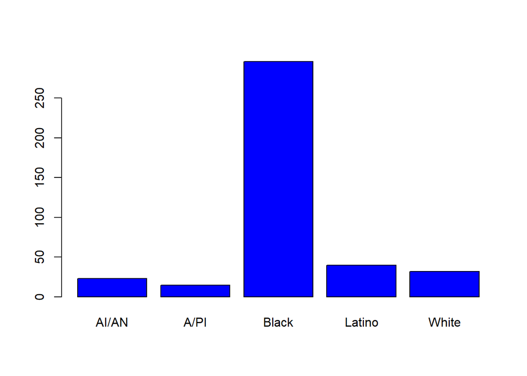

```r
barplot(m.rate,names.arg=names.short,col=4) # bar chart with names and color
```

## Horizontal Bar Chart

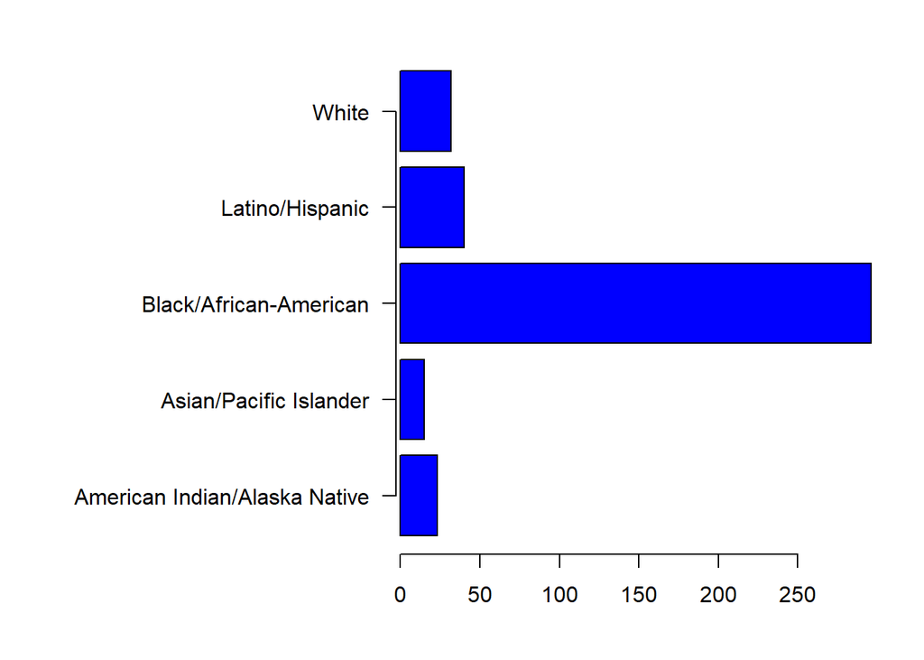

```r
parsave <- par()
par(mar=c(4,15,2,2))     # specify margins for long labels
barplot(m.rate,names.arg=as.character(race.ethnic),col=4,horiz=TRUE,las=1,axis.lty=1)
```

```r
par(parsave)
```

## Cluster Bar Chart

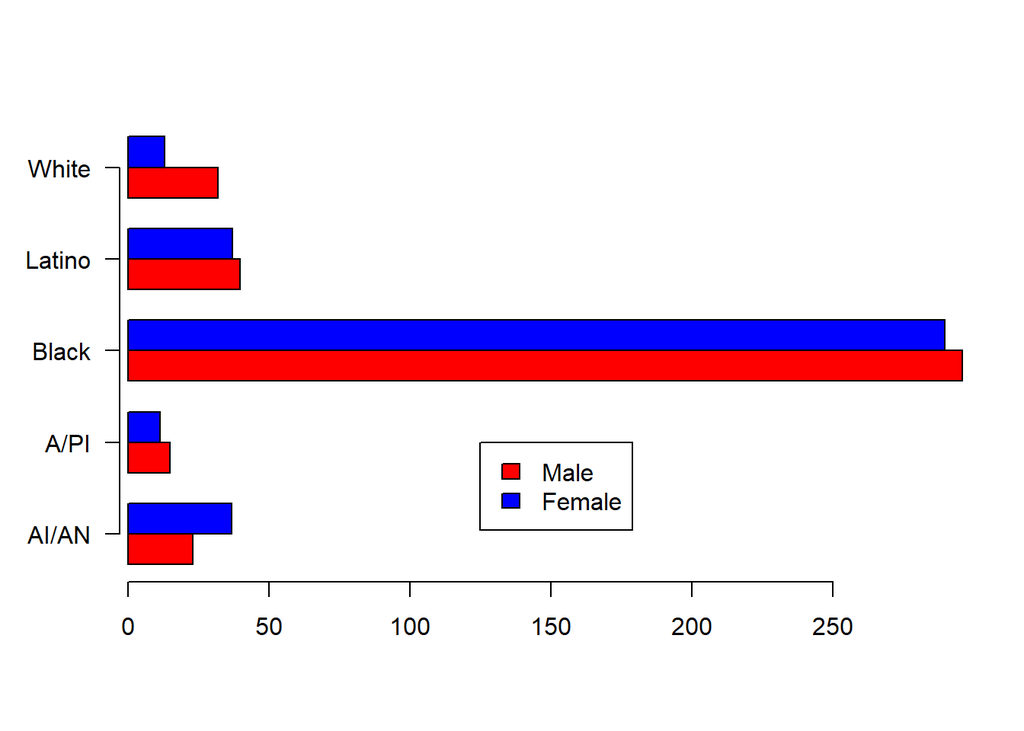

```r
temp <- barplot(rbind(m.rate,f.rate),names.arg=names.short, col=c(2,4),horiz=TRUE,
        las=1,
        beside=TRUE,
        axis.lty=1)
legend(x=125,y=5,legend=c("Male","Female"),fil=c(2,4))
```

## Stacked Bar Chart

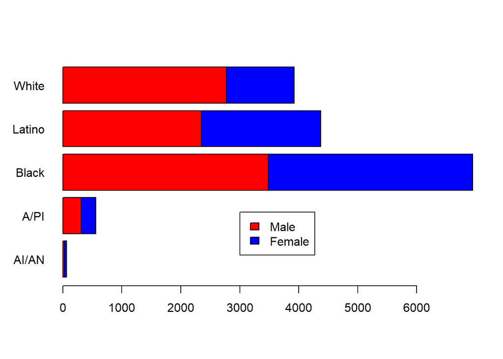

```r
temp <- barplot(rbind(m.cases,f.cases),names.arg=names.short,col=c(2,4), horiz=TRUE,las=1,
            beside=FALSE)     #Stacked Bar Chart
legend(x=3000,y=2,legend=c("Male","Female"),fil=c(2,4))
```

## Pie Charts

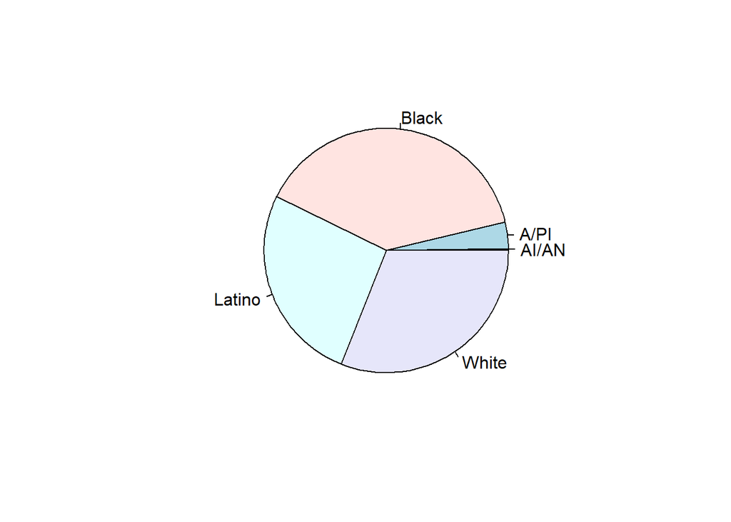

```r
pie(m.cases,labels=names.short)
```

## Dot Charts

```r
dotchart(m.cases,labels=as.character(race.ethnic),cex=.7)   #CEX is a parameter to change relative font size
```

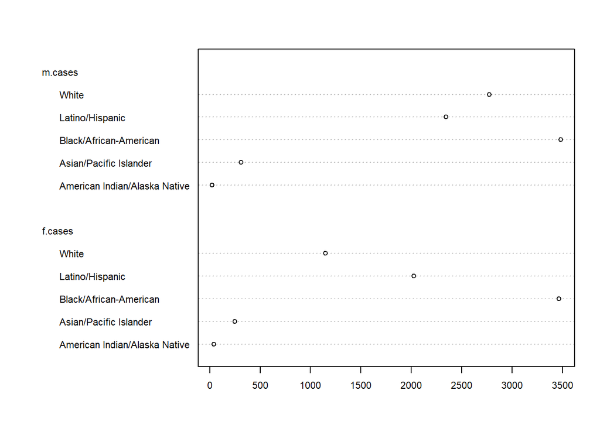

```r
dotchart(cbind(m.cases,f.cases),labels=as.character(race.ethnic),cex=.7)
```

detach(ca.gc)

# Chapter 4 — Plots Examining Relationships —

R is particularly powerful for looking at relationships in data, and has many related types of graphical routines for this area. A common function that is very powerful and flexible for looking at relationships is the “plot” function. Two simple applications of the plot function are a line chart, showing a trend over time, and a scatter plot showing the relationship between two continuous, or basically continuous, variables.

### Generate some vectors for plotting

```r
x0 <- 1:50
x  <- x0 + rnorm(50)*5
y  <- x  + rnorm(50)*5
```

## Line Graphs and Scatterplot

```r
plot(x )               #basic ?
```

```r
plot(x0,x)            #basic plot
```

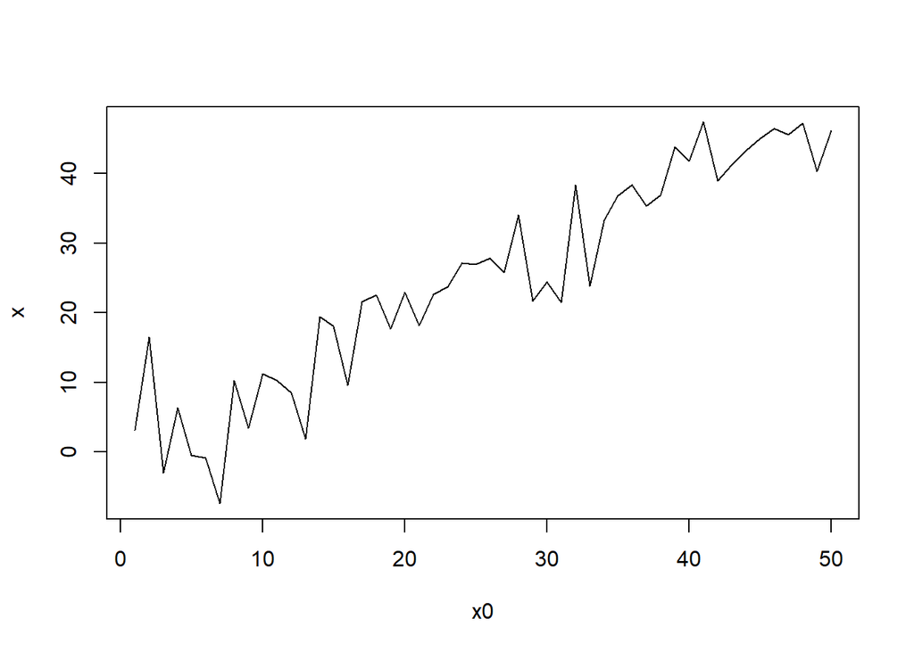

```r
plot(x0,x,type="l")   #basic line gr
```

## line/point “type” parameter

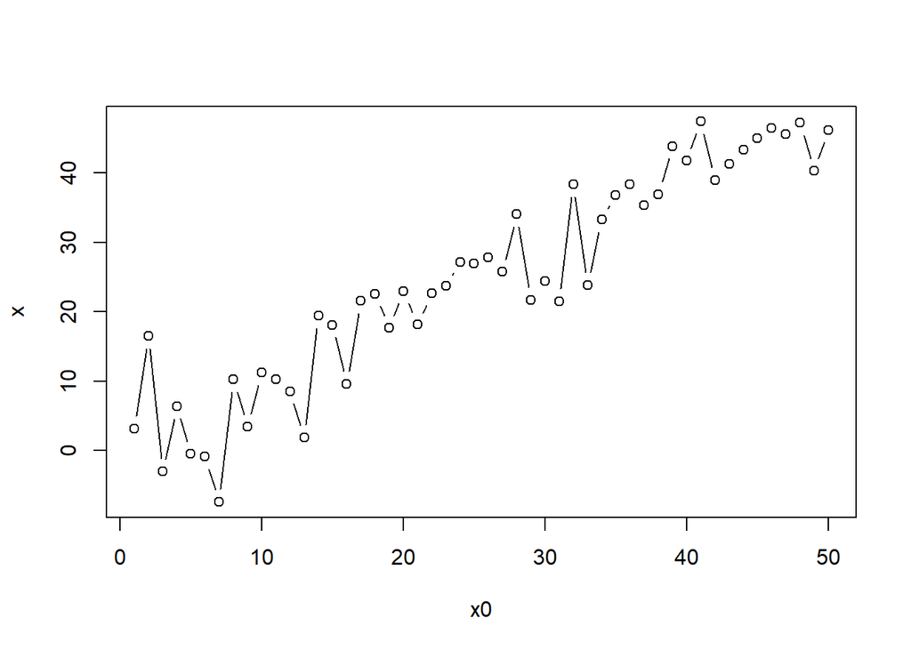

```r
plot(x0,x,type="b")
```

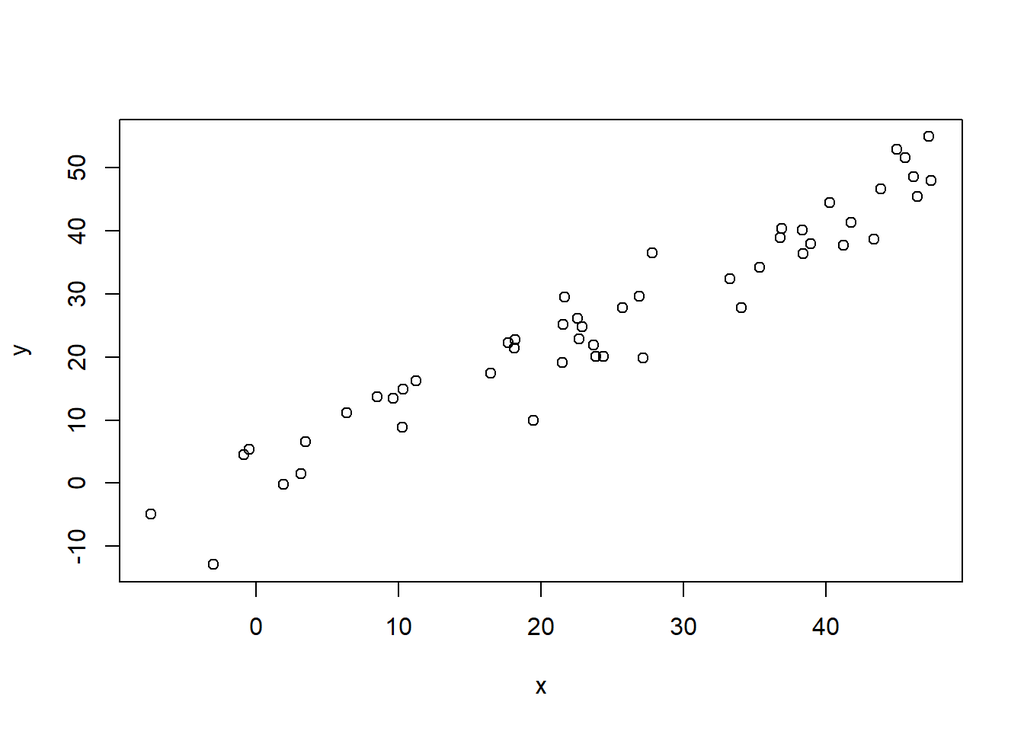

```r
plot(x,y)               #basic scatter plot
```

```r
## plot(x,y,type="l")    #basically doesn't make sense
```

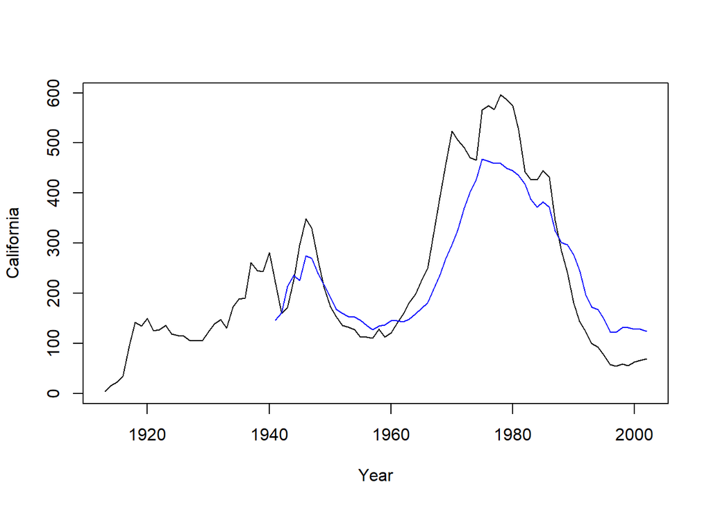

```r
attach(gc.trend) # for convenience
plot(Year,California,type="l")
lines(Year,US,col=4)            # Add line to create mult-line graph
```

Use matplot to create multi-line graph with one command; I generally don’t use ‘for real’ becuase I generally want more control, but good here to show ‘line types’

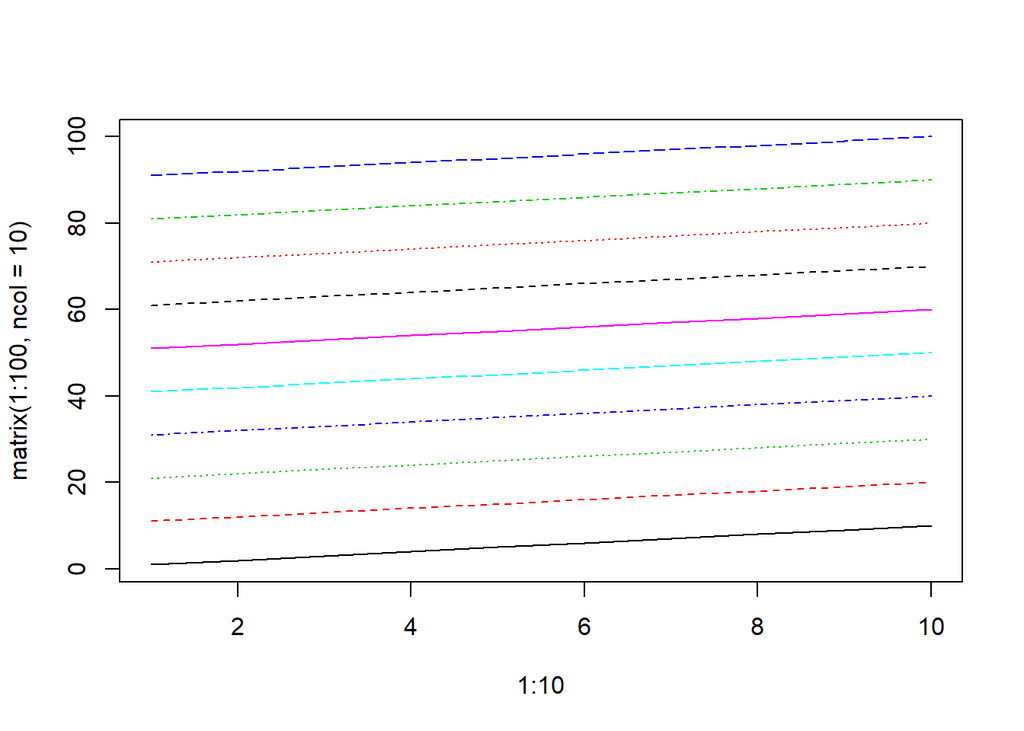

```r
matplot(1:10,matrix(1:100,ncol=10),type="l")
```

### Line Types

http://www.statmethods.net/advgraphs/parameters.html http://www.stat.tamu.edu/~jkim/Rlinestyle.pdf http://cran.r-project.org/doc/contrib/Short-refcard.pdf

## Boxplot by Categorical Variable

SFMHS Data

```r
attach(sfmhs) # for convenience
plot(SEXPREF,CD4) # a scatterplot...
```

```r
boxplot(SEXPREF,CD4)
```

```r
plot(as.factor(SEXPREF),CD4) # same as boxplot...
```

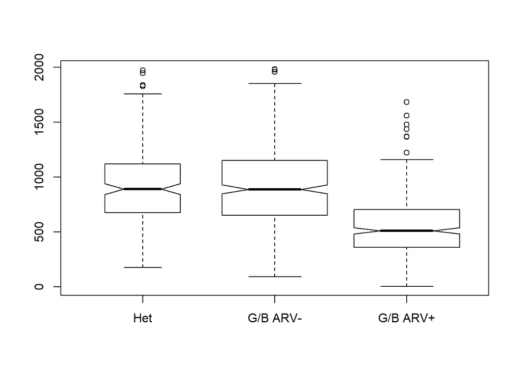

```r
attach(sfmhs) # for convenience
CD4[CD4 > 2000] <- NA
group <- SEXPREF-1
group[group==1 & ARV==1] <- 2
group <- factor(group,labels=c("Het","G/B ARV-","G/B ARV+"))
plot(group,CD4,varwidth=TRUE,notch=TRUE)
```

```r
detach(sfmhs)
```

## Plotting symbols proportional to data

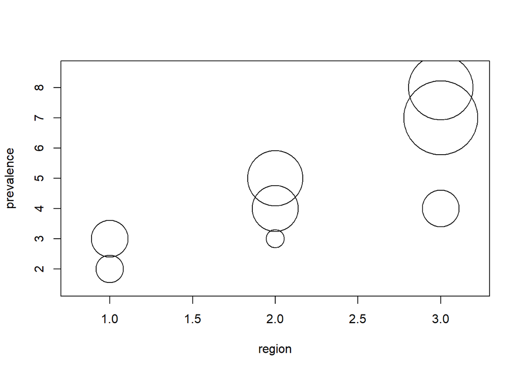

```r
region      <- c(1,1,1,2,2,2,3,3,3)
prevalence  <- c(2,3,2,3,5,4,7,4,8)
number      <- c(3,4,3,2,6,5,8,4,7)
symbols(region,prevalence,circles=number,inches=.5)
```

## “Ploting” 2 by 2 tables (SKIP)

```r
outbreak <- matrix(c(200,40,5,23),byrow=TRUE,nrow=2,dimnames=list(c("Ate It","Didn't"),c("Ill","Well")))
outbreak
```

```
##        Ill Well
## Ate It 200   40
## Didn't   5   23
```

```r
chisq.test(outbreak,correct = F)
```

```
##
##  Pearson's Chi-squared test
##
## data:  outbreak
## X-squared = 59.783, df = 1, p-value = 1.059e-14
```

```r
library(Epi) # Epi Package
twoby2(outbreak)
```

```
## 2 by 2 table analysis:
## ------------------------------------------------------
## Outcome   : Ill
## Comparing : Ate It vs. Didn't
##
##        Ill Well    P(Ill) 95% conf. interval
## Ate It 200   40    0.8333    0.7807   0.8753
## Didn't   5   23    0.1786    0.0763   0.3638
##
##                                     95% conf. interval
##              Relative Risk:  4.6667    2.1044  10.3488
##          Sample Odds Ratio: 23.0000    8.2526  64.1010
## Conditional MLE Odds Ratio: 22.5902    7.8063  80.5950
##     Probability difference:  0.6548    0.4699   0.7630
##
##              Exact P-value: 0
##         Asymptotic P-value: 0
## ------------------------------------------------------
```

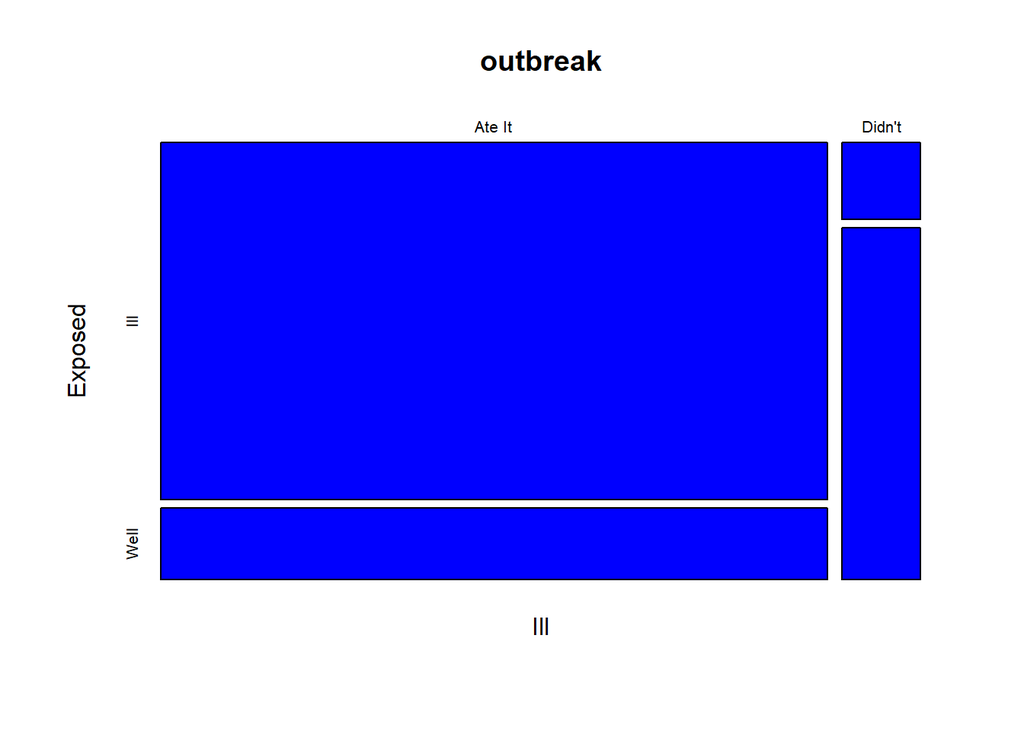

```r
mosaicplot(outbreak,col = "blue",xlab = "Ill",ylab = "Exposed")
```

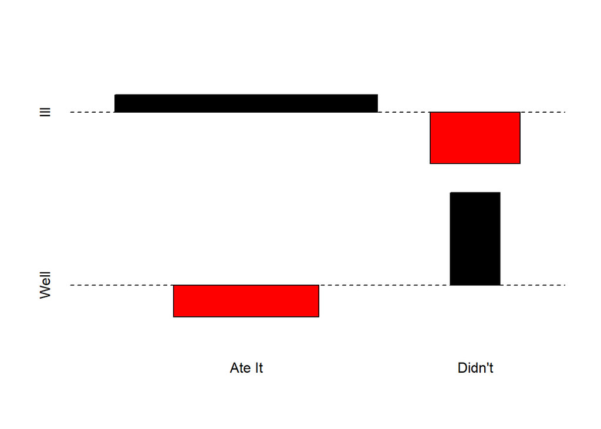

```r
assocplot(outbreak)
```

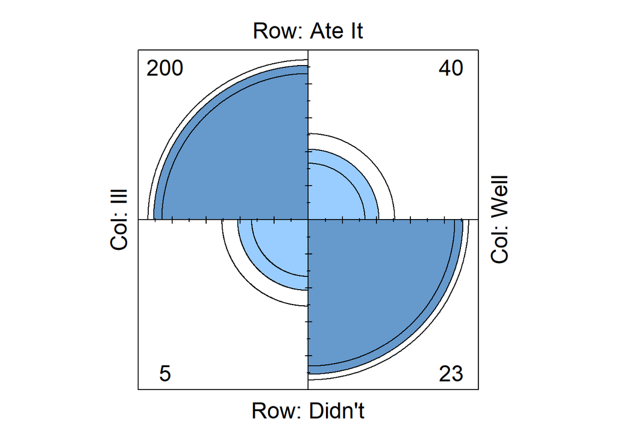

```r
fourfoldplot(outbreak)
```

LOTS and LOTS of other types of plots in R

# Chapter 5 — NUTS AND BOLTS —

## Titles and Axes Titles

Titles can be created using the “title” function, the “main” parameter in a plot function, or the “mtext” function discussed later

x and y axis labels can be created using the “xlab” and “ylab” parameters in a plot function, or using the “mtext” function

### main, xlab, & ylab approach:

```r
attach(usSTD) # Back to the US STD Data
plot(gcf,gcm)
```

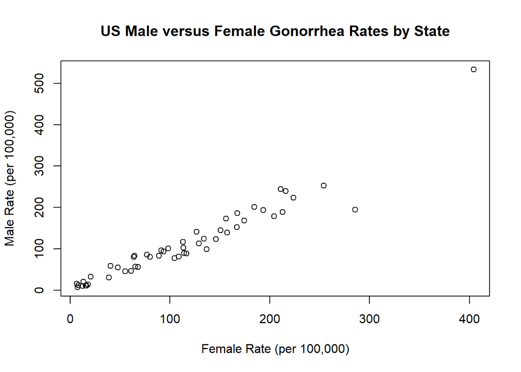

```r
attach(usSTD) # Back to the US STD Data
plot(gcf,gcm,main="US Male versus Female Gonorrhea Rates by State",
             xlab="Female Rate (per 100,000)",
             ylab="Male Rate (per 100,000)")
```

## Adding text to axes using mtext and axis:

mtext is a powerful function to any type of text (including numbers) to a specific margin of a figure, at specific coordinates, on a specific “line”; uses the coordinates generated by the plot function

axis is also powerful for adding text to the margins (it can also be used to adjust the tics and other aspects of the margins)

### mtext

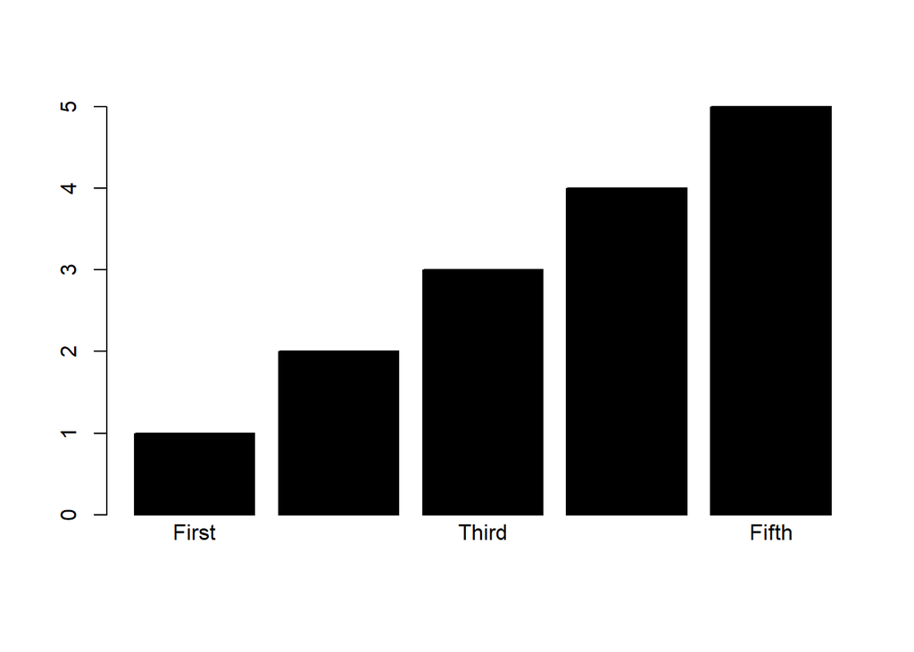

```r
x <- barplot(1:5,col=1)
my.labels <-c("First","second","Third","Fourth","Fifth")
my.marks <- c(1,3,5)
mtext(my.labels[my.marks],side=1,at=x[my.marks])
```

“at” specifies where along the axis to place the labels; you WILL use this…

### using the axis function

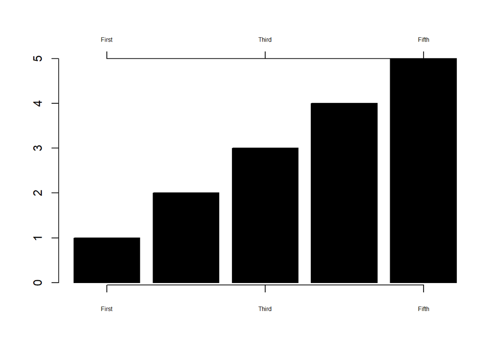

```r
barplot(1:5,col=1)
axis(1, at=x[my.marks],labels=my.labels[my.marks],cex.axis=.5)
axis(3, at=x[my.marks],labels=my.labels[my.marks],cex.axis=.5)
```

## Legends and Labels

```r
attach(gc.trend)
```

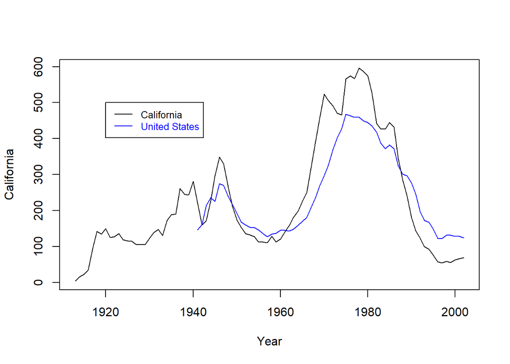

```r
plot(Year,California,type="l")
lines(Year,US,col=4) # add US line

# Add a legend using STANDARD LEGEND function arguments

legend(1920,500,legend=c("California","United States"),cex=.8,lty=1,col=c(1,4),text.col=c(1,4))
```

## Adding text to the body of a figure using the Text Function

TEXT is a useful function for adding text strings to any specified location inside a figure based on x,y coordinates

add some annotation using text function, specifying coordinates and using locator

text(1985,580,“Peak”) text(locator(),“Nadir”)

The TEXT function can be used to directly label lines (better than using a legend in many situations) or to build complex legends, when the legend function is inadequate

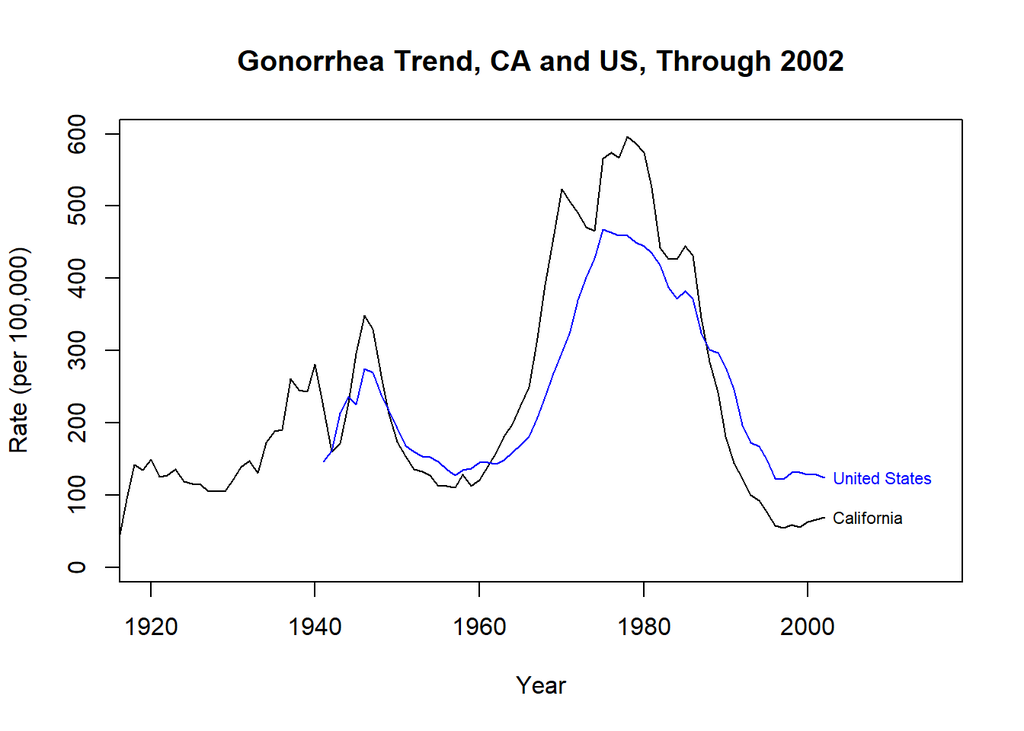

```r
plot(Year,California,type="l",xlim=c(1920,2015),
     main="Gonorrhea Trend, CA and US, Through 2002",
     xlab="Year",
     ylab="Rate (per 100,000)")
lines(Year,US,col=4) # add US line

text(2003,California[length(California)],"California",cex=.7,adj=c(0,.5))
text(2003,US[length(California)],"United States",cex=.7,adj=c(0,.5),col=4)
```

```r
detach(gc.trend)
```

## Text “Data”

### Using text for detailed labeling marking of points

Read in file that has “fips” codes and state abbreviations and merge the usSTD data set and this fips data set

```r
usSTD   <- read.table(paste0(myPlace,"/RawData/ctgcps2002.csv"),sep=",",na.strings="",header=T)
fips    <- read.table(paste0(myPlace,"/RawData/fipsdata.csv"),sep=",",na.strings="",header=T,as.is=T)
usWork  <- merge(usSTD,fips,by.x="FIPSCODE",by.y="FIPScode")
attach(usWork)
```

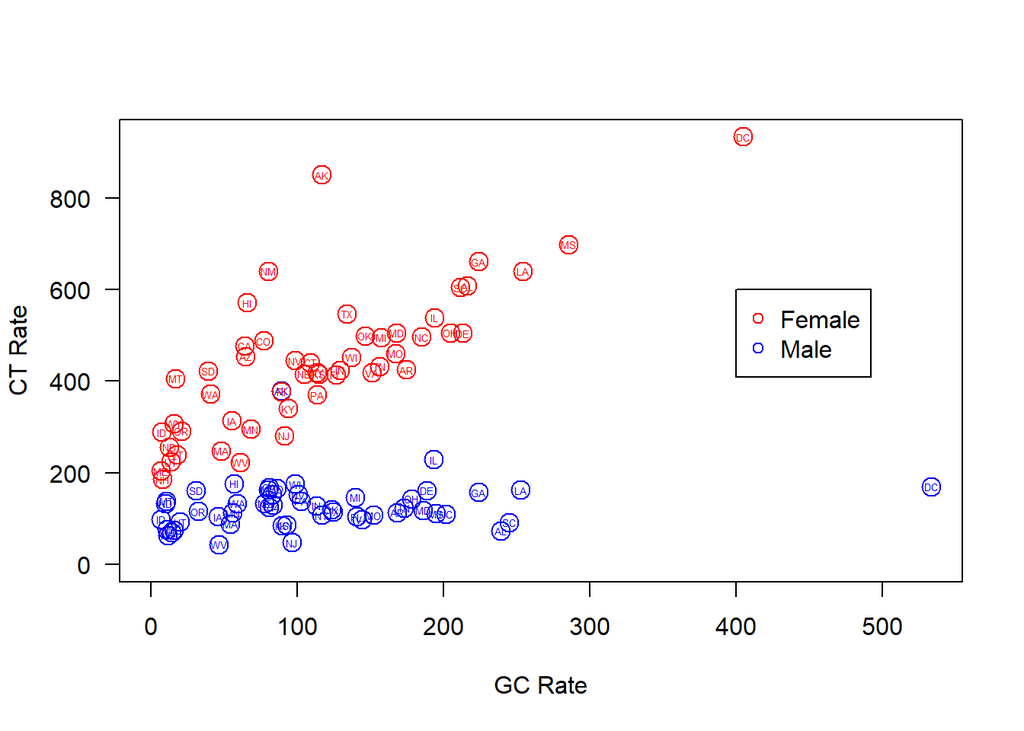

```r
plot(gcm,ctm,
     pch=1,cex=1.75,col=4,las=1,
     xlim=c(0,max(gcm,gcf)),
     ylim=c(0,max(ctm,ctf)),
     xlab="GC Rate",
     ylab="CT Rate")
text(gcm,ctm,StateAb,cex=.4,col=4)
points(gcf,ctf,pch=1,cex=1.75,col=2)
text(gcf,ctf,StateAb,cex=.4,col=2)
legend(400,600,c("Female","Male"),col=c(2,4),pch=1)
```

### Can use “text” function to make custom legend

text(450,600,“Female”,col=2,adj=0,cex=.75) text(450,550,“Male”,col=4,adj=0,cex=.75) points(440,600,pch=1,col=2,cex=1.75) points(440,550,pch=1,col=4,cex=1.75)

### Line type (lty) and line width (lwd) reference plot

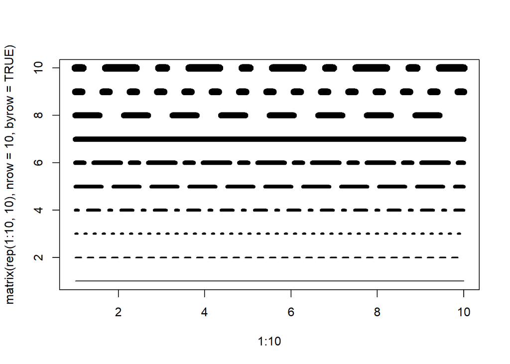

```r
matplot(1:10,matrix(rep(1:10,10),nrow=10,byrow=TRUE),type="l",col="black",lty=1:10,lwd=1:10)
```

or one can use the character strings “blank”,“solid”,“dashed”,“dotted”,“dotdash”,“longdash”, “twodash”, or go crazy and a string of up to 8 characters (from `c(0:9,“A”:“F”)’) may be given, giving the length of line segments which are alternatively drawn and skipped.

### Plotting symbol reference

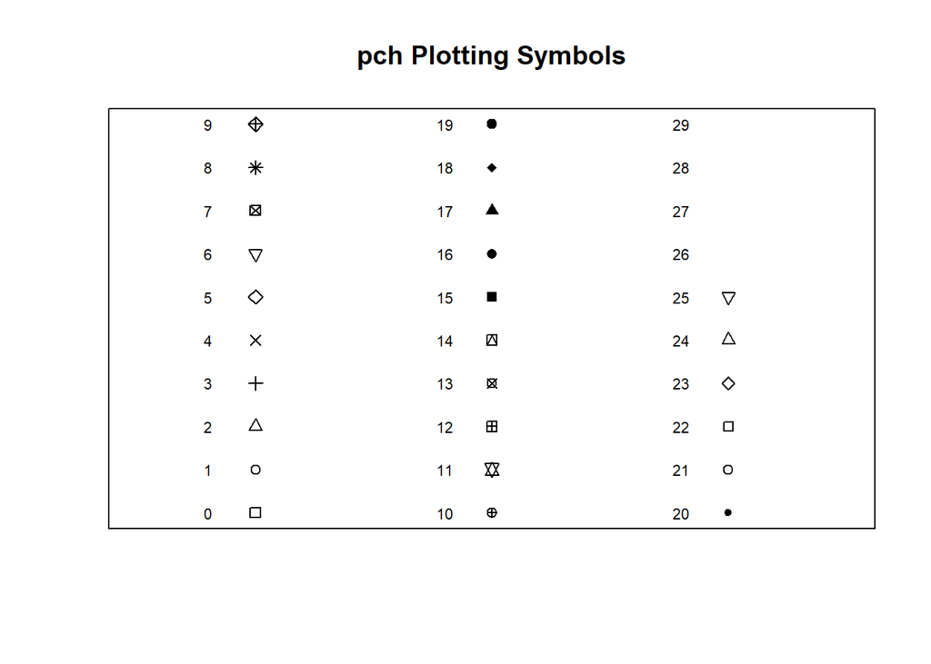

```r
plot(rep(c(1,2,3),each=10),rep(0:9,3),pch=0:29,xlim=c(.5,3.5),xaxt="n",yaxt="n",ylab=NA,xlab=NA)
title("pch Plotting Symbols")
text(rep(c(1,2,3)-.2,each=10),rep(0:9,3),as.character(0:29),cex=.7)
```